# clusterExperiment Vignette

### 5.1.5 Dealing with large numbers of clusterings

A good first check before running `clusterMany` is to determine how many clusterings you are asking for. `clusterMany` has some limited internal checks to not do unnecessary duplicates (e.g. `removeSil` only works with some clusterFunctions so `clusterMany` would detect that), but generally takes all combinations. This can take a while for more complicated clustering techniques, so it is a good idea to check what you are getting into. You can do this by running `clusterMany` with `run=FALSE`.

In the following we consider expanding our original clustering choices to consider individual choices of $K$ (rather than just `findBestK=TRUE`).

```r
checkParam<-clusterMany(se, clusterFunction="pam", ks=2:10,
                        removeSil=c(TRUE,FALSE), isCount=TRUE,
                        dimReduce=c("PCA","var"),
                        nVarDims=c(100,500,1000),nPCADims=c(5,15,50),run=FALSE)
dim(checkParam$paramMatrix) #number of rows is the number of clusterings
```

```
## [1] 108  12
```

Each row of the matrix `checkParam$paramMatrix` is a requested clustering (the columns indicate the value of a possible parameter). Our selections indicate 108 different clusterings (!).

We can set `ncores` argument to have these clusterings done in parallel. If `ncores>1`, the parallelization is done via `mclapply` and should not be done in the Rgui interface (see help pages for `mclapply`).

## 5.2 Create a unified cluster from many clusters with `combineMany`

After creating many clusterings, `combineMany` finds a single cluster based on what samples were in the same clusters throughout the many clusters found by `clusterMany`. While subsampling the data helps be robust to outlying samples, combining across many clustering parameters can help be robust to choice in parameters, particularly when the parameters give roughly similar numbers of clusters.

As mentioned in the Quick Start section, the default option for `combineMany` is to only define a cluster when *all* of the samples are in the same clusters across *all* clusterings. However, this is generally too conservative and just results in most samples not being assigned to a cluster.

Instead `combineMany` has a parameter `proportion` that governs in what proportion of clusterings the samples should be together. Internally, `combineMany` makes a coClustering matrix $D$. Like the $D$ created by subsampling in `clusterMany`, the coClustering matrix takes on values 0-1 for the proportion of times the samples are together in the clustering. This $D$ matrix is saved in the `ce` object and can be visualized with `plotCoClustering` (which is just a call to `plotHeatmap`). Recall the one we last made in the QuickStart, with our last call to `combineMany` (`proportion=0.7` and `minSize=3`).

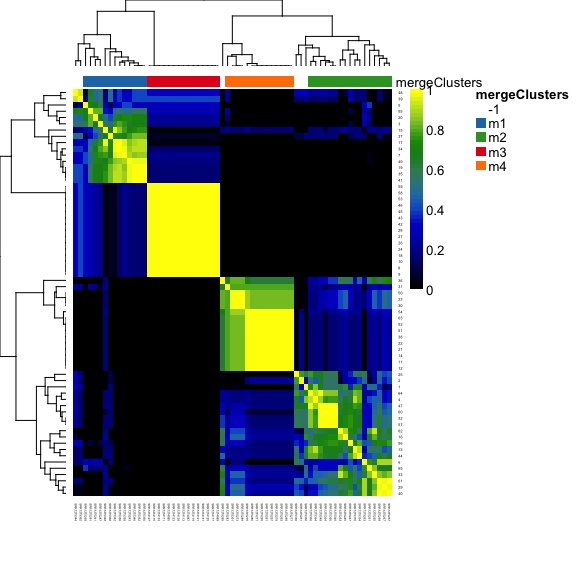

```r
plotCoClustering(ce)
```

`combineMany` performs the clustering by running a “01” clustering algorithm on the $D$ matrix of percentage co-clustering (the default being “hierarchical01”). The `alpha` argument to the 01 clustering is `1-proportion`. Also passed to the clustering algorithm is the parameter `minSize` which sets the minimum size of a cluster.

We can also manually choose the set of clusters to use in `combineMany` with the argument `whichClusters`. Here we choose only the clusters that correspond to using dimensionality reduction using the most variable features. We also set `minSize` to be lower than the default of 5 to allow for smaller clusters

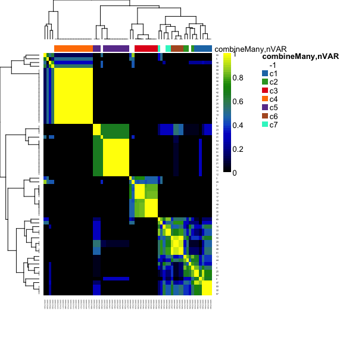

```r
wh<-grep("nVAR",clusterLabels(ce))
ce<-combineMany(ce,whichCluster=wh,proportion=0.7,minSize=3,
                clusterLabel="combineMany,nVAR")
plotCoClustering(ce)
```

We can compare to all of our other versions of `combineMany`. While they do not all have `clusterTypes` equal to “combineMany” (only the most recent call has clusterType exactly equal to “combineMany”), they all have “combineMany” as part of their clusterType, even though they have different clusterLabels (and now we’ll see that it was useful to give them different labels!)

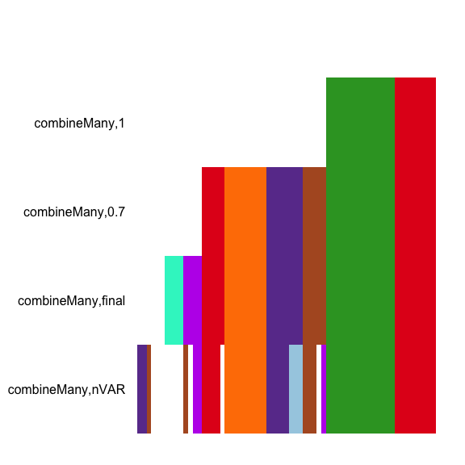

```r
wh<-grep("combineMany",clusterTypes(ce))
par(mar=plotCMar)
plotClusters(ce,whichClusters=rev(wh),axisLine=-1)
```

**Treatment of Unclustered assignments** -1 values are treated separately in the calculation. In particular, they are not considered in the calculation of percentage co-clustering – the percent co-clustering is taken only with respect to those clusterings where both samples were assigned. However, a post-processing is done to the clusters found from running the clustering on the $D$ matrix. For each sample, the percentage of times that they were marked -1 in the clusterings is calculated. If this percentage is greater than the argument `propUnassigned` then the sample is marked as -1 in the clustering returned by `combineMany`.

**Good scenarios for running `combineMany`** Varying certain parameters result in clusterings better for `combineMany` than other sets of parameters. In particular, if there are huge discrepancies in the set of clusterings given to `combineMany`, the results will be a shattering of the samples into many small clusters. Similarly, if the number of clusters $K$ is very different, the end result will likely be like that of the large $K$, and how much value that is (rather than just picking the clustering with the largest $K$), is debatable. However, for “01” clustering algorithms or clusterings using the sequential algorithm, varying the underlying parameters $\alpha$ or $k_0$ often results in roughly similar clusterings across the parameters so that creating a consensus across them is highly informative.

## 5.3 Creating a Hierarchy of Clusters and Merging clusters

As mentioned above, we find that merging clusters together based on the extent of differential expression between the features to be a useful method for combining many small clusters.

We provide a method for doing this that consists of two steps. Making a hierarchy between the clusterings and then estimating the amount of differential expression at each branch of the hierarchy.

### 5.3.1 makeDendrogram

`makeDendrogram` creates a hierarchical clustering of the clusters as determined by the primaryCluster of the `ClusterExperiment` object. In addition to being used for merging clusters, the dendrograms created by `makeDendrogram` are also useful for ordering the clusters in `plotHeatmap` as has been shown above.

`makeDendrogam` performs hierarchical clustering of the cluster medoids (after transformation of the data) and provides a dendrogram that will order the samples according to this clustering of the clusters. The hierarchical ordering of the dendrograms is saved internally in the `ClusterExperiment` object.

Like clustering, the dendrogram can depend on what features are included from the data. The same options for clustering are available for the hierarchical clustering of the clusters, namely choices of dimensionality reduction via `dimReduce` and the number of dimensions via `ndims`.

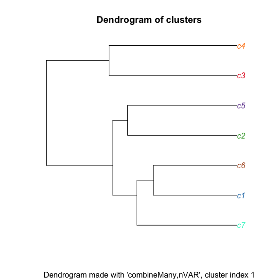

```r
ce<-makeDendrogram(ce,dimReduce="var",ndims=500)
plotDendrogram(ce)
```

Notice that the plot of the dendrogram shows the hierarchy of the clusters (and color codes them according to the colors stored in colorLegend slot).

Recall that the most recent clustering made is from our call to `combineMany`, where we experimented with using on some of the clusterings from `clusterMany`, so that is our current primaryCluster:

```r
show(ce)
```

```
## class: ClusterExperiment
## dim: 7069 65
## Primary cluster type: combineMany
## Primary cluster label: combineMany,nVAR
## Table of clusters (of primary clustering):
## -1 c1 c2 c3 c4 c5 c6 c7
## 10  7  3  9 15 13  5  3
## Total number of clusterings: 41
## Dendrogram run on 'combineMany,nVAR' (cluster index: 1)
## -----------
## Workflow progress:
## clusterMany run? Yes
## combineMany run? Yes
## makeDendrogram run? Yes
## mergeClusters run? No
```

This is the clustering from combining only the clusterings from `clusterMany` that use the top most variable genes. Because it is the primaryCluster, it was the clustering that was used by default to make the dendrogram.

We might prefer to get back to the dendrogram based on our `combineMany` in quick start (the “combineMany, final” clustering). We’ve lost that dendrogram when we called `makeDendrogram` again. However, we can rerun `makeDendrogram` and choose a different clustering from which to make the dendrogram.

To vary the display, we’ll show the display where we put blocks of color instead of names (`labelType="colorblock"`) and we also decide to show the leaves as the individual samples instead of the clusters (`leafType="sample"`); the combination of which gives us color blocks equal to the size of the clusterings.

[figure not shown]

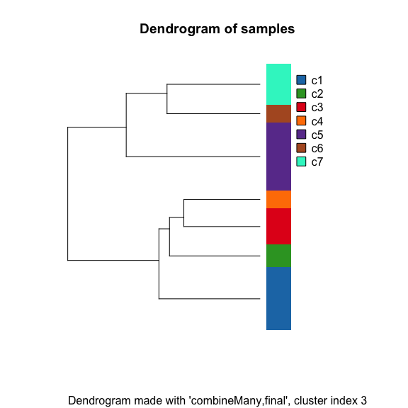

```r
ce<-makeDendrogram(ce,dimReduce="var",ndims=500,
                   whichCluster="combineMany,final")
plotDendrogram(ce,leafType="sample",labelType="colorblock")
```

Note that the clusterType of this clustering is not “combineMany”, but “combineMany.x”, where “x” indicates what iteration it was:

```r
clusterTypes(ce)[which(clusterLabels(ce)=="combineMany,final")]
```

```
## [1] "combineMany.3"
```

We can choose reset this past call to `combineMany` to the current ‘combineMany’ output (which will also set this clustering to be the primaryCluster). We don’t need to recall `makeDendrogram`, since we already used this clustering to make the dendrogram by our explicit call of the argument `whichCluster`.

```r
ce<-setToCurrent(ce,whichCluster="combineMany,final")
show(ce)
```

```
## class: ClusterExperiment
## dim: 7069 65
## Primary cluster type: combineMany
## Primary cluster label: combineMany,final
## Table of clusters (of primary clustering):
## -1 c1 c2 c3 c4 c5 c6 c7
##  6  4  8  5  9 15 14  4
## Total number of clusterings: 41
## Dendrogram run on 'combineMany,final' (cluster index: 3)
## -----------
## Workflow progress:
## clusterMany run? Yes
## combineMany run? Yes
## makeDendrogram run? Yes
## mergeClusters run? No
```

### 5.3.2 Merging clusters with little differential expression

We then can use this hierarchy of clusters to merge clusters that show little difference in expression. We do this by testing, for each node of the dendrogram, for which features is the mean of the set of clusters to the right split of the node is equal to the mean on the left split. This is done via the `getBestFeatures` (see section on getBestFeatures), where the `type` argument is set to “Dendro”.

Starting at the bottom of the tree, those clusters that have the percentage of features with differential expression below a certain value (determined by the argument `cutoff`) are merged into a larger cluster. This testing of differences and merging continues until the estimated percentage of non-null DE features is above `cutoff`. This means lower values of `cutoff` result in less merging of clusters. There are multiple methods of estimation of the percentage of non-null features implemented. The option `mergeMethod="adjP"` which we showed earlier is the simplest: the proportion found significant by calculating the proportion of DE genes at a given False Discovery Rate threshold (using the Benjamini-Hochberg procedure). However, other more sophisticated methods are also implemented (see the help of `mergeClusters`).

Notice that `mergeClusters` will always run based on the clustering that made the currently existing dendrogram. So it is always good to check that it is what we expect.

```r
ce
```

```
## class: ClusterExperiment
## dim: 7069 65
## Primary cluster type: combineMany
## Primary cluster label: combineMany,final
## Table of clusters (of primary clustering):
## -1 c1 c2 c3 c4 c5 c6 c7
##  6  4  8  5  9 15 14  4
## Total number of clusterings: 41
## Dendrogram run on 'combineMany,final' (cluster index: 3)
## -----------
## Workflow progress:
## clusterMany run? Yes
## combineMany run? Yes
## makeDendrogram run? Yes
## mergeClusters run? No
```

`mergeClusters` can also be run without merging the cluster, and simply drawing a plot showing the dendrogram along with the estimates of the percentage of non-null features to aid in deciding a cutoff and method. By setting `plotInfo="all"`, all of the estimates of the different methods are displayed simultaneously, while before in the QuickStart, we only showed the default values.

```
## Note: Merging will be done on ' combineMany,final ', with clustering index 3
```

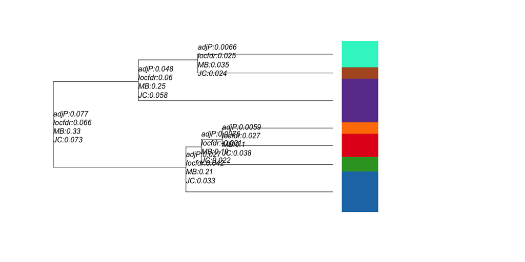

```r
mergeClusters(ce,mergeMethod="none",plotInfo="all")
```

Now we can pick a cutoff. We’ll give it a label to keep it separate from the previous run we had made.

```r
ce<-mergeClusters(ce,cutoff=0.05,mergeMethod="adjP",clusterLabel="mergeClusters,v2")
```

```
## Note: Merging will be done on ' combineMany,final ', with clustering index 3
```

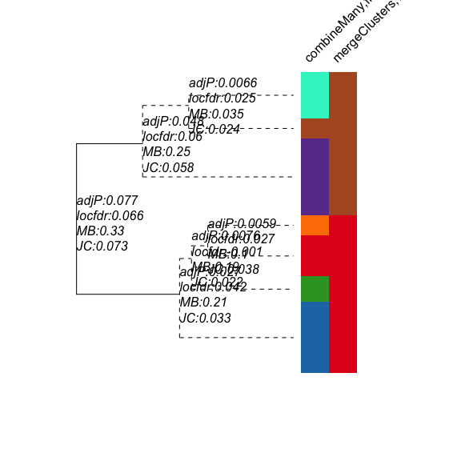

```r
ce
```

```
## class: ClusterExperiment
## dim: 7069 65
## Primary cluster type: mergeClusters
## Primary cluster label: mergeClusters,v2
## Table of clusters (of primary clustering):
## -1 m1 m2
##  6 28 31
## Total number of clusterings: 42
## Dendrogram run on 'combineMany,final' (cluster index: 4)
## -----------
## Workflow progress:
## clusterMany run? Yes
## combineMany run? Yes
## makeDendrogram run? Yes
## mergeClusters run? Yes
```

If we want to rerun `mergeClusters` with a different cutoff, we can go ahead and do that (notice in the summary above, that the dendrogram is still there, and associated with the same cluster, so we can rerun `mergeClusters` and know that it will still pull from the same input clustering from `combineMany` as we were before)

```r
ce<-mergeClusters(ce,cutoff=0.15,mergeMethod="MB",
                  clusterLabel="mergeClusters,v3")
```

```
## Note: Merging will be done on ' combineMany,final ', with clustering index 4
```

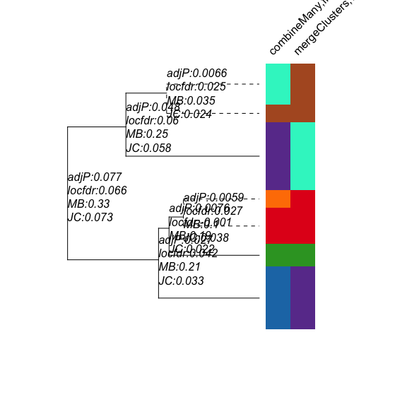

```r
ce
```

```
## class: ClusterExperiment
## dim: 7069 65
## Primary cluster type: mergeClusters
## Primary cluster label: mergeClusters,v3
## Table of clusters (of primary clustering):
## -1 m1 m2 m3 m4 m5
##  6 13 12  5 15 14
## Total number of clusterings: 43
## Dendrogram run on 'combineMany,final' (cluster index: 5)
## -----------
## Workflow progress:
## clusterMany run? Yes
## combineMany run? Yes
## makeDendrogram run? Yes
## mergeClusters run? Yes
```

Note, we can turn off plotting completely by setting `plot=FALSE`.

## 5.4 Keeping track of and rerunning elements of the workflow

The commands we have shown above show a workflow which continually saves the results over the previous object, so that additional information just gets added to the existing object.

What happens if some parts of the clustering workflow are re-run? For example, in the above we reran parts of the workflow when we talked about them in more detail, or to experiment with parameter settings.

The workflow commands check for existing clusters of the workflow (based on the `clusterTypes` of the clusterings). If there exist clusterings from previous runs *and* such clusterings came from calls that are “downstream” of the requested clustering, then the method will change their clusterTypes value by adding a “.i”, where $i$ is a numerical index keeping track of replicate calls.

For example, suppose we rerun ‘combineMany’, say with a different parameter choice of the proportion similarity to require. Then `combineMany` searches the existing clusterings in the input object. Any existing `combineMany` results will have their `clusterTypes` changed from `combineMany` to `combineMany.x`, where $x$ is the largest such number needed to be greater than any existing `combineMany.x` (after all, you might do this many times!). Their labels will also be updated if they just have the default label, but if the user has given different labels to the clusters those will be preserved.

Moreover, since `mergeClusters` is downstream of `combineMany` in the workflow, currently existing `mergeClusters` will also get bumped to `mergeClusters.x`. However, `clusterMany` is upstream of `combineMany` (i.e. you expect there to be existing `clusterMany` before you run `combineMany`) so nothing will happen to `clusterMany`.

This is handled internally, and may never be apparent to the user unless they choose `whichClusters="all"` in a plotting command. Indeed this is one reason to always pick `whichClusters="workflow"`, so that these saved previous versions are not displayed.

However, if the user wants to “go back” to previous versions and make them the current iteration, we have seen that the `setToCurrent` command will do this. `setToCurrent` follows the same process as described above, only with an existing cluster set to the current part of the pipeline.

Note that there is nothing that governs or protects the `clusterTypes` values to be of a certain kind. This means that if the user decides to name a clusterTypes of a clustering one of these protected names, that is allowed. However, it could clearly create some havoc if done poorly.

**Erasing old clusters** You can also choose to have **all** old versions erased by choosing the options `eraseOld=TRUE` in the call to `clusterMany`, `combineMany`,`mergeClusters` and/or `setToCurrent`. `eraseOld=TRUE` in any of these functions will delete ALL past workflow results except for those that are both in the current workflow *and* “upstream” of the requested command. You can also manually remove clusters with `removeClusters`.

**Finding workflow iterations** Sometimes which numbered iteration a particular call is in will not be obvious if there are many calls to the workflow. You may have a `mergeClusters.2` cluster but no `mergeClusters.1` because of an upstream workflow call in the middle that bumped the iteration value up to 2 without ever making a `mergeClusters.1`. If you really want to, you can see more about the existing iterations and where they are in the `clusterMatrix`. “0” refers to the current iteration; otherwise the smaller the iteration number, the earlier it was run.

```r
workflowClusterTable(ce)
```

```
##                Iteration
## Type             0  1  2  3  4
##   final          0  0  0  0  0
##   mergeClusters  1  0  0  1  1
##   combineMany    1  1  1  0  1
##   clusterMany   36  0  0  0  0
```

Explicit details about every workflow cluster and their index in `clusterMatrix` is given by `workflowClusterDetails`:

```r
head(workflowClusterDetails(ce),8)
```

```
##   index          type iteration             label
## 1     1 mergeClusters         0  mergeClusters,v3
## 2     2 mergeClusters         4  mergeClusters,v2
## 3     3   combineMany         4  combineMany,nVAR
## 4     4 mergeClusters         3   mergeClusters.3
## 5     5   combineMany         0 combineMany,final
## 6     6   combineMany         2   combineMany,0.7
## 7     7   combineMany         1     combineMany,1
## 8     8   clusterMany         0      nVAR=100,k=5
```

**A note on the `whichCluster` argument** Many functions take the `whichCluster` argument for identifying a clustering or clusterings on which to perform an action. These arguments all act similarly across functions, and allow the user to give character arguments. As described above, these can be shortcuts like “workflow”, or they can match either clusterTypes or clusterLabels of the object. It is important to note that matching is first done to clusterTypes, and then if not successful to clusterLabels. Since neither clusterTypes nor clusterLabels is guaranteed to be unique, the user should be careful in how they make the call. And, of course, `whichCluster` arguments can also take explicit numeric integers that identify the column(s) of the clusterMatrix that should be used.

### 5.4.1 Designate a Final Clustering

A final protected clusterTypes is “final”. This is not created by any method, but can be set to be the clusterType of a clustering by the user (via the `clusterTypes` command). Any clustering marked `final` will be considered one of the workflow values for commands like `whichClusters="workflow"`. However, they will NOT be renamed with “.x” or removed if `eraseOld=TRUE`. This is a way for a user to ‘save’ a clustering as important/final so it will not be changed internally by any method, yet still have it show up with the “workflow” clustering results. There is no limit to the number of such clusters that are so marked, but the utility of doing so will drop if too many such clusters are chosen.

For best functionality, particularly if a user has determined a single final clustering after completing clustering, a user will probably want to set the primaryClusterIndex to be that of the final cluster and rerun makeDendrogram. This will help in plotting and visualizing. The `setToFinal` command does this.

Here we will demonstrate marking a cluster as final. We go back to our previous mergeClusters that we found with `cutoff=0.05` and mark it as our final clustering. First we need to find which cluster it is. We see from our above call to the workflow functions above, that it is clusterType equal to “mergeClusters.4” and label equal to “mergeClusters,v2”. In our call to `setToFinal` we will decide to change it’s label as well.

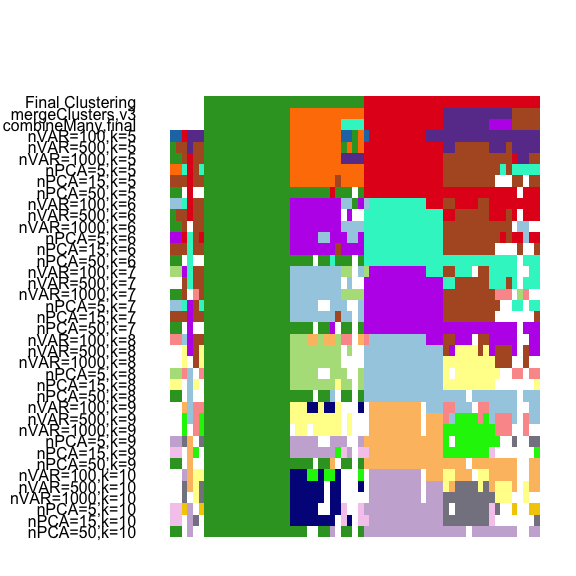

```r
ce<-setToFinal(ce,whichCluster="mergeClusters,v2",
               clusterLabel="Final Clustering")
par(mar=plotCMar)
plotClusters(ce,whichClusters="workflow")
```

Note that because it is labeled as “final” it shows up automatically in “workflow” clusters in our `plotClusters` plot. It has also been set as our primaryCluster and has the new clusterLabel we gave it in the call to `setToFinal`.

This didn’t get rid of our undesired `mergeClusters` result that is most recent. It still shows up as “the” mergeClusters result. This might be undesired. We could remove that “mergeClusters” result with `removeClusters`. Alternatively, we could manually change the clusterTypes to `mergeClusters.x` so that it doesn’t show up as current. A cleaner way to do this would have been to first set the desired cluster (“mergeClusters.4”) to the most current iteration with `setToCurrent`, which would have bumped up the existing `mergeClusters` result to be no longer current.

## 5.5 RSEC

The clustering workflow described so far is a generalization of our RSEC algorithm for single-cell sequencing data. The RSEC algorithm is particularly oriented around using subsampling and sequential discovery of clusters to find very robust signals.

In particular, `RSEC` is a single function that follows the entire workflow described above, but makes the choices to set `subsample=TRUE` and `sequential=TRUE`. Furthermore, the only clustering functions that are allowed are the “01” types (currently “hierarchical01” and “tight”). This removes a number of options from clusterMany, making for a slightly reduced set of arguments. `RSEC` also implements the `combineMany`, `makeDendrogram` and `mergeClusters` steps, again with not all arguments available to be set. Furthermore, the defaults set in `RSEC` are those we choose for our algorithm, and occassionally vary from stand-alone method. The final output is a `clusterExperiment` object as you would get from following the workflow.

We give the following correspondence to help see what arguments of each component are fixed by RSEC, and which are allowed to be set by the user (as well as their correspondence to arguments in the workflow functions).

|  | Arguments Internally Fixed | Arguments for the user | Correspondence | Notes |
| --- | --- | --- | --- | --- |
| *clusterMany* |  |  |  |  |
| - | sequential=TRUE | k0s | ks | only sets ‘k0’, no other k |
| - | distFunction=NA | clusterFunction |  | only tight or hierarchical01 |
| - | removeSil=FALSE | dimReduce |  |  |
| - | subsample=TRUE | nVarDims |  |  |
| - | silCutoff=0 | nPCADims |  |  |
| - |  | alphas |  |  |
| - |  | betas |  |  |
| - |  | minSizes |  |  |
| - |  | mainClusterArgs |  |  |
| - |  | subsampleArgs |  |  |
| - |  | seqArgs |  |  |
| - |  | run |  |  |
| - |  | ncores |  |  |
| - |  | random.seed |  |  |
| - |  | isCount |  |  |
| - |  | transFun |  |  |
| *combineMany* |  |  |  |  |
| - | propUnassigned = *(default)* | combineProportion | proportion |  |
| - | combineMinSize | minSize |  |  |
| *makeDendrogram* |  |  |  |  |
| - | ignoreUnassignedVar=TRUE | dendroReduce | dimReduce |  |
| - | unassignedSamples= *(default)* | dendroNDims | ndims |  |
| *mergeClusters* |  |  |  |  |
| - | plot=FALSE | mergeMethod |  |  |
| - |  | mergeCutoff | cutoff |  |
| - |  | isCount |  | used for both mergeMethod and clusterMany |

# 6 Finding Features related to a Clustering

The function `getBestFeatures` finds features in the data that are strongly differentiated between the clusters of a given clustering. Finding the best features is generally the last step in the workflow, once a final clustering has been decided upon, though as we have seen it is also called internally in `mergeClusters` to decide between which clusters to merge together.

The function `getBestFeatures` calls `limma` (Smyth 2004, Ritchie et al. (2015)) on input data to determine the gene features most associated with a particular clustering. `getBestFeatures` picks the `primaryCluster` of a `ClusterExperiment` object as the clustering to use to find features. If the standard workflow is followed, this will be the last completed step (usually the result of `mergeClusters` or manually choosing a final cluster via `setToFinal`). The primaryCluster can of course be changed by setting `primaryClusterIndex` to point to a different clustering.

```r
wh<-which(clusterLabels(ce)=="mergeClusters,v3")
if(length(wh)==1) primaryClusterIndex(ce)<-wh else stop()
```

The basic implementation is that of `limma` which fits a linear model per feature and tests for the significance of parameters of that linear model. The main contribution of `getBestFeatures` is to interface with `limma` so as to pick appropriate parameters or tests for comparing clusters. Naturally, `getBestFeatures` also seamlessly works with `ClusterExperiment` objects to minimize the burden on the user. The output is in the form of `topTable` in `limma`, i.e. a data.frame giving the relevant features, the p-value, etc.

## 6.1 Types of Significance Tests

There are several choices of what is the most appropriate test to determine whether a feature is differentially expressed across the clusterings. All of these methods first fit a linear model where the clusters categories of the clustering is the explanatory factor in the model (samples with -1 or -2 are ignored). The methods differ only in what significance tests they then perform, which is controlled by the argument `type`. By default, `getBestFeatures` finds significant genes based on a F-test between the clusters (`type="F"`). This is a very standard test to compare clusters, which is why it is the default, however it may not be the one that gives the best or most specific results. Indeed, in our “Quick Start”, we did not use the $F$ test, but rather all pair-wise comparisons between the clusters.

The $F$ test is a test for whether there are *any* differences in expression between the clusters for a feature. Three other options are available that try to detect instead specific kinds of differences between clusters that might be of greater interest. Specifically, these differences are encoded as “contrasts”, meaning specific types of differences between the means of clusters.

Note that for all of these contrasts, we are making use of all of the data, not just the samples in the particular cluster pairs being compared. This means the variance is estimated with all the samples. Indeed, the same linear model is being used for all of these comparisons.

### 6.1.1 All Pairwise

The option `type="Pairs"`, which we saw earlier, performs all pair-wise tests between the clusters for each feature, testing for each pair of clusters whether the mean of the feature is different between the two clusters. Here is the example from above using all pairwise comparisons:

```r
pairsAllTop<-getBestFeatures(ce,contrastType="Pairs",p.value=0.05)
dim(pairsAllTop)
```

```
## [1] 100   9
```

```r
head(pairsAllTop)
```

```
##   IndexInOriginal Contrast Feature     logFC   AveExpr         t
## 1             552    X1-X2  BCL11B -8.912981  3.848816 -8.174292
## 2            2210    X1-X2    GLI3  6.690233  5.473713  6.845450
## 3            6565    X1-X2     VIM  6.818923  7.749640  6.694650
## 4            3309    X1-X2    MIAT -7.097724  7.325323 -6.518758
## 5            5745    X1-X2   STMN2 -6.692038  8.314910 -6.449138
## 6            1744    X1-X2    ENO1  5.615936 10.554084  6.370684
##        P.Value    adj.P.Val         B
## 1 9.355870e-12 7.780782e-09 15.078592
## 2 2.492757e-09 8.595756e-07 10.328588
## 3 4.665952e-09 1.499255e-06  9.790555
## 4 9.663605e-09 2.689450e-06  9.164671
## 5 1.287780e-08 3.422298e-06  8.917550
## 6 1.778408e-08 4.411075e-06  8.639557
```

Notice that compared to the quick start guide, We didn’t set the parameter `number` which is passed to topTable, so we can get out *at most* 10 significant features for each contrast/comparison (because the default value of `number` in `topTable` is 10). Similarly, if we didn’t set a value for `p.value`, `topTable` would return the top `number` genes per contrast, regardless of whether they were all significant or not. These are the defaults of `topTable`, which we purposefully do not modify, but we urge the user to read the documentation of `topTable` carefully to understand what is being asked for. In the QuickStart, we set `number=NROW(ce)` to make sure we got *all* significant genes.

In addition to the columns provided by `topTable`, the column “Contrast” tells us what pairwise contrast the result is from. “X1-X2” means a comparison of cluster 1 and cluster 2. The column “IndexInOriginal” gives the index of the gene to the original input data matrix, namely `assay(ce)`. The other columns are given by `topTable` (with the column “Feature” renamed – it is usually “ProbeID” in `limma`).

### 6.1.2 One Against All

The choice `type="OneAgainsAll"` performs a comparison of a cluster against the mean of all of the other clusters.

```r
best1vsAll<-getBestFeatures(ce,contrastType="OneAgainstAll",p.value=0.05)
head(best1vsAll)
```

```
##   IndexInOriginal ContrastName           Contrast Feature     logFC
## 1             538            1 X1-(X2+X3+X4+X5)/4    BCAN  6.760057
## 2            2210            1 X1-(X2+X3+X4+X5)/4    GLI3  6.400933
## 3            3849            1 X1-(X2+X3+X4+X5)/4    NRG1  6.536965
## 4            1284            1 X1-(X2+X3+X4+X5)/4   CXADR -6.342056
## 5             435            1 X1-(X2+X3+X4+X5)/4  ATP1A2  6.878362
## 6            2455            1 X1-(X2+X3+X4+X5)/4    HES1  5.493516
##    AveExpr         t      P.Value    adj.P.Val        B
## 1 2.302045  8.440550 3.043138e-12 2.195096e-09 16.77940
## 2 5.473713  8.159071 9.976469e-12 6.079626e-09 15.72254
## 3 2.401928  8.074085 1.427970e-11 8.011365e-09 15.40276
## 4 9.885678 -7.637553 9.000285e-11 4.185725e-08 13.75715
## 5 2.465131  7.590835 1.095771e-10 4.965390e-08 13.58089
## 6 3.593156  7.341638 3.125841e-10 1.150863e-07 12.64084
```

### 6.1.3 Dendrogram

The option `type="Dendro"` is more complex; it assumes that there is a hierarchy of the clusters (created by `makeDendrogram` and stored in the `ClusterExperiment` object). Then for each *node* of the dendrogram, `getBestFeatures` defines a contrast or comparison of the mean expression between the daughter nodes.

Notice the problem if we try to run the command, however.

```r
bestDendroTest1<-getBestFeatures(ce,contrastType="Dendro",p.value=0.05)
```

```
## Error in .local(x, ...): Primary cluster does not match the cluster on which the dendrogram was made. Either replace existing dendrogram with on using the primary cluster (via 'makeDendrogram'), or reset primaryCluster with 'primaryClusterIndex' to be equal to index of 'dendo_index' slot
```

This is because the dendrogram we have does not correspond to the primaryCluster.

```r
show(ce)
```

```
## class: ClusterExperiment
## dim: 7069 65
## Primary cluster type: mergeClusters
## Primary cluster label: mergeClusters,v3
## Table of clusters (of primary clustering):
## -1 m1 m2 m3 m4 m5
##  6 13 12  5 15 14
## Total number of clusterings: 43
## Dendrogram run on 'combineMany,final' (cluster index: 5)
## -----------
## Workflow progress:
## clusterMany run? Yes
## combineMany run? Yes
## makeDendrogram run? Yes
## mergeClusters run? Yes
```

`getBestFeatures` only works on the primaryCluster, and has noticed that the dendrogram in our `ce` object was not made from the primaryCluster. So we need to rerun `makeDendrogram` with our primaryCluster. It’s regardless generally a good idea to make sure the dendrogram you have is the one you want.

```r
ce<-makeDendrogram(ce,dimReduce="var",ndims=500)
bestDendro<-getBestFeatures(ce,contrastType="Dendro",p.value=0.05)
head(bestDendro)
```

```
##   IndexInOriginal ContrastName               Contrast Feature     logFC
## 1            2210        Node1 (X5+X2+X3)/3-(X1+X4)/2    GLI3 -7.784163
## 2            5745        Node1 (X5+X2+X3)/3-(X1+X4)/2   STMN2  7.997804
## 3            4285        Node1 (X5+X2+X3)/3-(X1+X4)/2  PLXNA2  7.827597
## 4            1465        Node1 (X5+X2+X3)/3-(X1+X4)/2    DLK1 -5.378393
## 5            4286        Node1 (X5+X2+X3)/3-(X1+X4)/2  PLXNA4  7.333733
## 6            2291        Node1 (X5+X2+X3)/3-(X1+X4)/2    GPC3 -4.600692
##    AveExpr          t      P.Value    adj.P.Val        B
## 1 5.473713 -11.618188 6.343480e-18 4.484206e-14 29.03659
## 2 8.314910  11.242937 2.834187e-17 1.335658e-13 27.69925
## 3 5.186352  10.797543 1.708818e-16 6.039816e-13 26.08662
## 4 2.916002 -10.623857 3.462440e-16 1.087822e-12 25.45063
## 5 4.970650  10.075551 3.279045e-15 7.726524e-12 23.41829
## 6 2.520560  -9.721577 1.419241e-14 3.086959e-11 22.08789
```

Again, there is both a “ContrastName” and “Contrast” column. The “Contrast” column identifies which clusters where on each side of the node (and hence commpared) and “ContrastName” is a name for the node.

```r
levels((bestDendro)$Contrast)
```

```
## [1] "(X5+X2+X3)/3-(X1+X4)/2" "X5-(X2+X3)/2"
## [3] "X1-X4"                  "X2-X3"
```

We can plot the dendrogram showing the node names to help make sense of which contrasts go with which nodes (plotDendrogram calls `plot.phylo` from the `ape` package and can take those arguments).

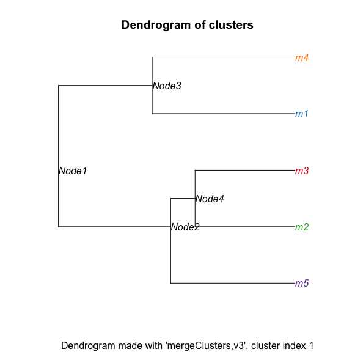

```r
plotDendrogram(ce,show.node.label=TRUE)
```

## 6.2 Analysis for count and other RNASeq data

The `getBestFeatures` method for `ClusterExperiment` objects has an argument `isCount`. If this is marked `TRUE` then the data in `assay(x)` is assumed to be counts, and the call to `limma` uses the `voom`(Law et al. 2014) correction. This correction deals with the mean-variance relationship that is found with count data. This means that the differential expression analysis is done on $log_2(x+0.5)$. This is *regardless of what transformation is stored in the `ClusterExperiment` object*! The `voom` call within `getBestFeatures` however, is by default set to `normalize.method = "none"` in the call to `voom` (though the user can set `normalize.method` in the call to `getBestFeatures`).

If instead `isCount=FALSE`, then `limma` is performed on `transform(x)`, i.e. the data after transformation of the data with the transformation stored in the `ClusterExperiment` object. In this case, there is no `voom` correction.

Unlike edgeR or DESeq, the voom correction does not explicitly require a count matrix, and therefore it has been proposed that it can be used on FPKM or TPM entries, or data normalized via RUV. Setting `isCount=TRUE` even if the data in the assay slot is not count will have this effect. However, the authors of the package do not recommend using voom on anything other than counts, see e.g. [this discussion](https://support.bioconductor.org/p/45749/).

## 6.3 Piping into other DE routines

Ultimately, for many settings, the user may prefer to use other techniques for differential expression analysis or have more control over certain aspects of it. The function `clusterContrasts` may be called by the user to get the contrasts that are defined within `getBestFeatures` (e.g. dendrogram contrasts or pairwise contrasts). These contrasts, which are in the format needed for `limma` can be piped into programs that allow for contrasts in their linear models like edgeR (Robinson, Mccarthy, and Smyth 2010) for mRNA-Seq; they can also be chosen to be returned in the formated needed by MAST (Finak et al. 2015) for single-cell sequencing by settting `outputType="MAST"`.

Similarly, more complicated normalizations, like RUV (Gagnon-Bartsch and Speed 2011), adjust each gene individually for unwanted batch or other variation within the linear model. In this case, a matrix $W$ that describes this variation should be included in the linear model. Again, this can be done in other programs, using the contrasts provided by `clusterContrasts`

## 6.4 Additional considerations

The user should be careful about questions of multiple comparisons when all of these multiple contrasts are being performed on each feature; the default is to correct across all of these tests (see the help of `getBestFeatures` and the argument `contrastAdj` for more). As noted in the introduction, p-values created in this way are reusing the data (since the data was also used for creating the clusters) and hence should not be considered valid p-values regardless.

As mentioned, `getBestFeatures` accepts arguments to `limma`’s function `topTable` to decide which genes should be returned (and in what order). In particular, we can set an adjusted p-value cutoff for each contrast, and set `number` to control the number of genes returned *for each contrast*. By setting `number` to be the length of all genes, and `p.value=0.05`, we can return all genes for each contrast that have adjusted p-values less than 0.05. All of the arguments to `topTable` regarding what results are returned and in what order can be given by the user at the call to `getBestFeatures`.

# 7 Session Information

# References

Finak, Greg, Andrew McDavid, Masanao Yajima, Jingyuan Deng, Vivian Gersuk, Alex K Shalek, Chloe K Slichter, et al. 2015. “MAST: a flexible statistical framework for assessing transcriptional changes and characterizing heterogeneity in single-cell RNA sequencing data.” *Genome Biology*, December, 1–13.

Gagnon-Bartsch, Johann A., and Terence P Speed. 2011. “Using control genes to correct for unwanted variation in microarray data.” *Biostatistics (Oxford, England)*, November.

Law, Charity W, Yunshun Chen, Wei Shi, and Gordon K Smyth. 2014. “voom: Precision weights unlock linear model analysis tools for RNA-seq read counts.” *Genome Biology* 15 (2): 1–17.

Ritchie, Matthew E, Belinda Phipson, Di Wu, Yifang Hu, Charity W Law, Wei Shi, and Gordon K Smyth. 2015. “limma powers differential expression analyses for RNA-sequencing and microarray studies.” *Nucleic Acids Research* 43 (7): e47–e47.

Robinson, Mark D, Davis J Mccarthy, and Gordon K Smyth. 2010. “edgeR: a Bioconductor package for differential expression analysis of digital gene expression data.” *Bioinformatics (Oxford, England)* 26 (1): 139–40.

Smyth, Gordon K. 2004. “Linear models and empirical bayes methods for assessing differential expression in microarray experiments.” *Statistical Applications in Genetics and Molecular Biology* 3 (1): Article3–25.

Tseng, George C., and Wing H. Wong. 2005. “Tight Clustering: A Resampling-Based Approach for Identifying Stable and Tight Patterns in Data.” *Biometrics* 61 (1): 10–16.